# Why is data visualization important?

Data is the basis for the work of a scientist. We collect, analyse, present and report this data. Visualising data is an important step of the scientific work. Figures summarise and condense a large amount of data and help to communicate the data to the viewers. Figures often say much more than numbers or tables.

Since figures, are an important part of scientific reports and papers, they need to be clear, attractive and convincing (Ref Wilkes). And this is a skill that needs to be learnt.

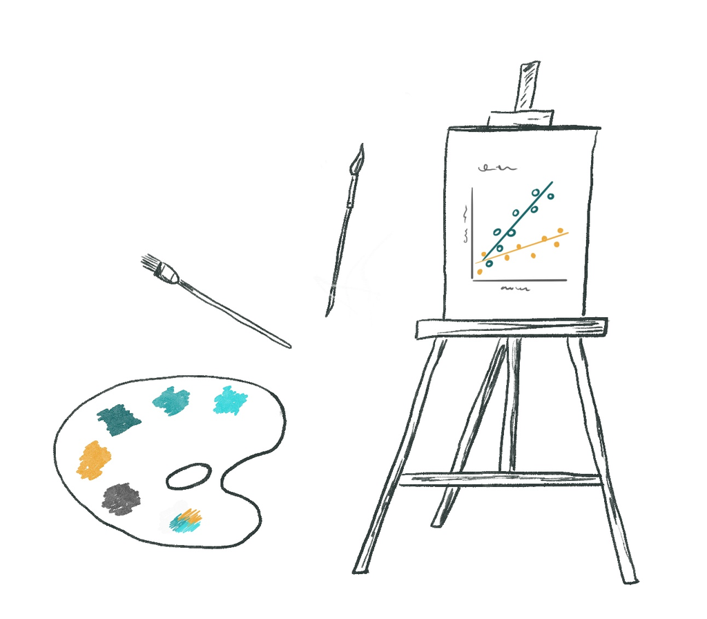